# Portfolio Report 4: Vectorization and parallel computing

Jake Spiteri

17/10/2019

# Vectorization

Vectorization is the process of replacing the use of loops in code, with a single operation applied elementwise to the vector. In vectorizing code, the multiple instructions running the same operation in a for loop are replaced by a single instruction which applies the operation to multiple elements in a vector.

Vectorization is much faster than using for loops in interpreted languages such as R, Matlab, and Python. To see this in practice, we will look at some examples.

We consider summing the cosine of each component of a vector.

```r
# set the seed for reproducibility
set.seed(123)

# uses a for loop
add_cos1 <- function(x) {
  sum <- 0
  for (i in 1:length(x)) {
    sum <- sum + cos(x[i])
  }
  return(sum)
}

# uses vectorization
add_cos2 <- function(x) sum(cos(x))

x = 1:1e7
t1 <- system.time(add_cos1(x))
t2 <- system.time(add_cos2(x))
```

```r
t1
```

```
##    user  system elapsed
##   0.780   0.001   0.781
```

```r
t2
```

```
##    user  system elapsed
##   0.252   0.024   0.276
```

At the time of running, this provided a speedup of 2.8 times. We also note that the vectorized code is also easier to read.

## High-dimensional vectorization

The example above shows that for loops are quite inefficient. It is now easy to see that nested for loops are very inefficient, and should be avoided.

There are many reasons we may want to use nested for loops. We may want to run a simulation $n_{sim}$ times, where each simulation consists of $n$ operations.

As an example, we consider the average value produced by tossing a fair six-sided die $n=500$ times. We expect our data to center around $\frac{1+2+3+4+5+6}{6}=3.5$. We simulate the experiment $n_{sim} = 1000$ times.

```r
toss_die1 <- function(nsim, n) {
  average <- numeric(nsim)
  for (i in 1:nsim) {
    counts <- numeric(n)
    for (j in 1:n) {
      counts[j] <- sample(1:6, 1)
    }
    average[i] <- mean(counts)
  }
  return(average)
}

toss_die2 <- function(nsim, n) {
  tosses <- matrix(sample(1:6, n*nsim, replace=TRUE), nrow=nsim, ncol=n)
  return(rowSums(tosses)/n)
}
```

We now test the runtime of the nested for loop version, and the vectorized version.

```r
nsim <- 1000; n <- 500
t1 <- system.time(toss_die1(nsim, n)); t1
```

```
##    user  system elapsed
##   1.974   0.001   1.974
```

```r
t2 <- system.time(toss_die2(nsim, n)); t2
```

```
##    user  system elapsed
##   0.017   0.000   0.016
```

We see that nested for loops are *very* slow and should be avoided when possible. In this case the vectorized code provides a speedup of 123 times! We will use the vectorized function in the following.

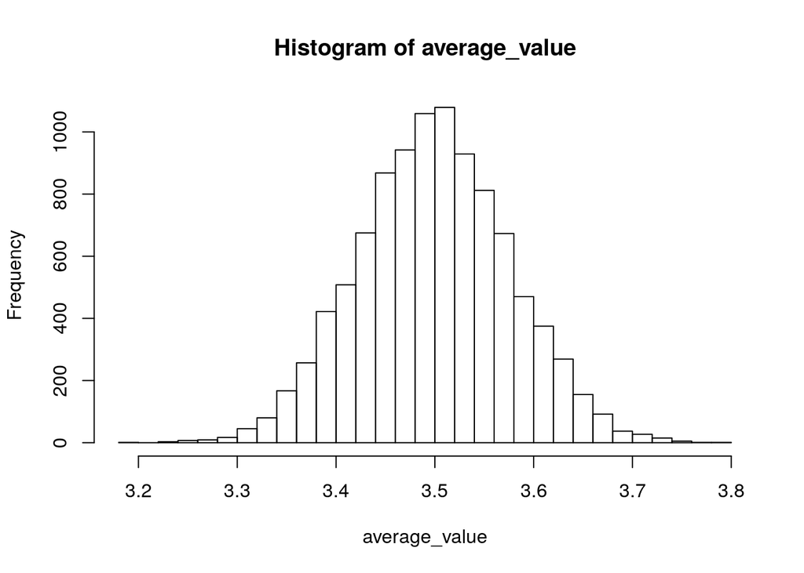

```r
nsim <- 10000; n <- 500
average_value <- toss_die2(nsim,n)
hist(average_value, breaks = 30)
```

Let’s look at a demonstration of Law of Large Numbers. We plot the cumulative mean as the number of throws increases.

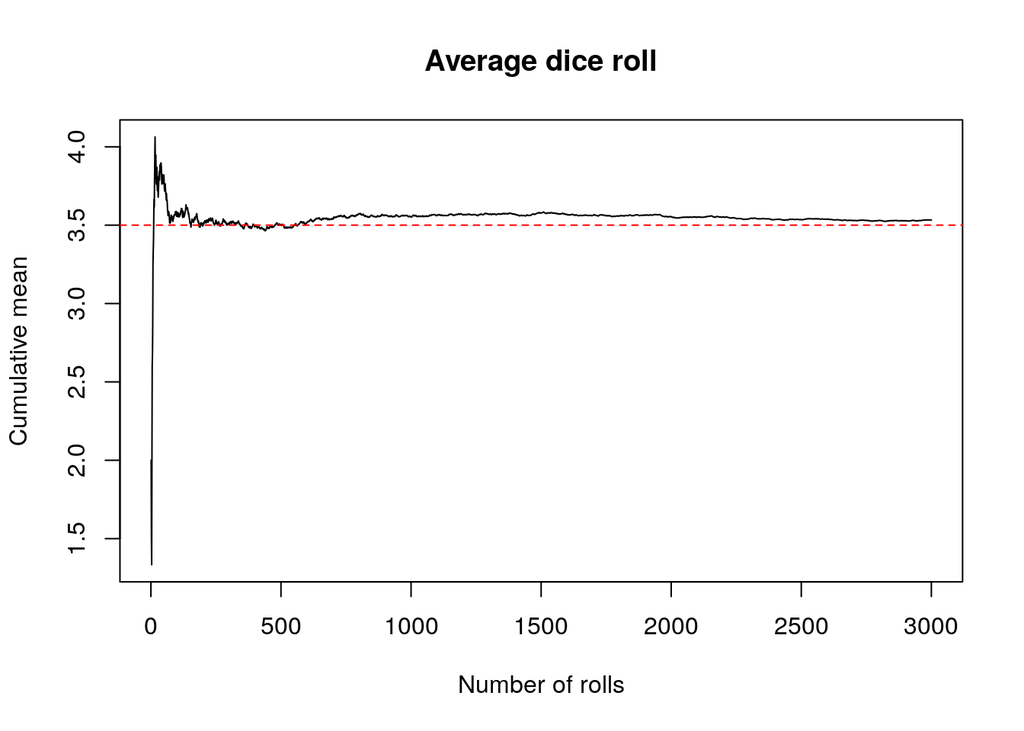

```r
nsim <- 3000; n <- 1
plot(1:nsim, cumsum(toss_die2(nsim, n))/1:nsim, type = 'l',
     main='Average dice roll',
     xlab = 'Number of rolls', ylab='Cumulative mean')
abline(h=3.5, col='red', lty = 2)
```